# SimulationIssue

Lan Luo

2022-04-19

## Data Simulation

Here I try to simulate a 2 factor model with 8 variables. No crossloadings here.

```r
N <- 1000
mu_latent <- c(0,0) #latent factor means #k=#of latent factors
varcov_latent <- matrix(c(1, .3, #var-cov matrix for latent factors
                .3, 1), nrow = 2, byrow = T)
Lambda <- matrix(c(1, .8, .7, .7, 0, 0, 0, 0, #loadings
                   0, 0, 0, 0, 1, .8, .7, .7), nrow = 8, byrow = F) #p*k matrix.p=#of observed variables.
Lambda
```

```
##      [,1] [,2]
## [1,]  1.0  0.0
## [2,]  0.8  0.0
## [3,]  0.7  0.0
## [4,]  0.7  0.0
## [5,]  0.0  1.0
## [6,]  0.0  0.8
## [7,]  0.0  0.7
## [8,]  0.0  0.7
```

```r
mu_epsilon <- rep(0, 8)
varcov_epsilon <- diag(c(1-1^2, #standardized
                         1-.8^2,
                         1-.7^2,
                         1-.7^2,
                         1-1^2,
                         1-.8^2,
                         1-.7^2,
                         1-.7^2),
                       nrow = 8)
varcov_epsilon
```

```
##      [,1] [,2] [,3] [,4] [,5] [,6] [,7] [,8]
## [1,]    0 0.00 0.00 0.00    0 0.00 0.00 0.00
## [2,]    0 0.36 0.00 0.00    0 0.00 0.00 0.00
## [3,]    0 0.00 0.51 0.00    0 0.00 0.00 0.00
## [4,]    0 0.00 0.00 0.51    0 0.00 0.00 0.00
## [5,]    0 0.00 0.00 0.00    0 0.00 0.00 0.00
## [6,]    0 0.00 0.00 0.00    0 0.36 0.00 0.00
## [7,]    0 0.00 0.00 0.00    0 0.00 0.51 0.00
## [8,]    0 0.00 0.00 0.00    0 0.00 0.00 0.51
```

```r
#generate latent factors
set.seed(1234)
zeta <- mvrnorm(n = N,
               mu = mu_latent,
               Sigma = varcov_latent) #n*p matrix
#generate residuals
set.seed(1234)
epsilon <- mvrnorm(n = N,
               mu =mu_epsilon,
               Sigma = varcov_epsilon) #p*n matrix

#### Generate the observed variable series ####
y <- matrix(0, nrow = N, ncol = 8)
for (p in 1:nrow(y)){
  y[p, ] <- Lambda %*% zeta[p, ] + epsilon[p, ]
}
head(y)
```

```
##             [,1]       [,2]       [,3]        [,4]        [,5]         [,6]       [,7]
## [1,] -0.26008265 -0.7031526 -0.4570546 -0.87750345 -1.68625239 -1.926725852 -2.0411569
## [2,]  0.04532048  0.2445573  0.3988334 -0.03942657  0.40202073 -0.166610678  0.4967048
## [3,]  1.78487502  0.8758443  1.4693715  1.17033191 -0.03626617 -0.145720369 -1.1245559
## [4,] -2.26705234 -1.9860437 -0.2735180 -0.73553940 -1.51527156 -0.062609693 -0.6069446
## [5,] -0.06990049 -0.3865986  1.0889882 -1.23146943  0.76184326  1.030536140  1.0352983
## [6,]  1.53553081  1.7376120  0.8190679  0.32813290 -0.71954020  0.006697499 -1.8647508
##            [,8]
## [1,] -2.0423940
## [2,]  0.4795386
## [3,]  0.7490596
## [4,] -2.7358533
## [5,]  0.8397466
## [6,] -0.1422819
```

```r
#identical to the following using matrix computation
gendata <- t(Lambda%*%t(zeta) + t(epsilon)) #transpose of p*n matrix
head(gendata)
```

```
##             [,1]       [,2]       [,3]        [,4]        [,5]         [,6]       [,7]
## [1,] -0.26008265 -0.7031526 -0.4570546 -0.87750345 -1.68625239 -1.926725852 -2.0411569
## [2,]  0.04532048  0.2445573  0.3988334 -0.03942657  0.40202073 -0.166610678  0.4967048
## [3,]  1.78487502  0.8758443  1.4693715  1.17033191 -0.03626617 -0.145720369 -1.1245559
## [4,] -2.26705234 -1.9860437 -0.2735180 -0.73553940 -1.51527156 -0.062609693 -0.6069446
## [5,] -0.06990049 -0.3865986  1.0889882 -1.23146943  0.76184326  1.030536140  1.0352983
## [6,]  1.53553081  1.7376120  0.8190679  0.32813290 -0.71954020  0.006697499 -1.8647508
##            [,8]
## [1,] -2.0423940
## [2,]  0.4795386
## [3,]  0.7490596
## [4,] -2.7358533
## [5,]  0.8397466
## [6,] -0.1422819
```

```r
cov(gendata)
```

```
##            [,1]       [,2]       [,3]       [,4]      [,5]      [,6]       [,7]      [,8]
## [1,]  0.9306379  0.7551214  0.6497299  0.6750007 0.3095849 0.2186399 -0.1581338 0.7659949
## [2,]  0.7551214  0.9529447  0.5331125  0.5504467 0.2589366 0.1812798 -0.1182221 0.6303744
## [3,]  0.6497299  0.5331125  0.9572632  0.4670041 0.2152837 0.1624458 -0.1115162 0.5338066
## [4,]  0.6750007  0.5504467  0.4670041  1.0116514 0.2110765 0.1580739 -0.1322529 0.5401906
## [5,]  0.3095849  0.2589366  0.2152837  0.2110765 1.0363669 0.8218762  1.1641140 1.3215689
## [6,]  0.2186399  0.1812798  0.1624458  0.1580739 0.8218762 0.9918477  0.9394032 1.0361502
## [7,] -0.1581338 -0.1182221 -0.1115162 -0.1322529 1.1641140 0.9394032  1.6129368 1.2604209
## [8,]  0.7659949  0.6303744  0.5338066  0.5401906 1.3215689 1.0361502  1.2604209 1.8496648
```

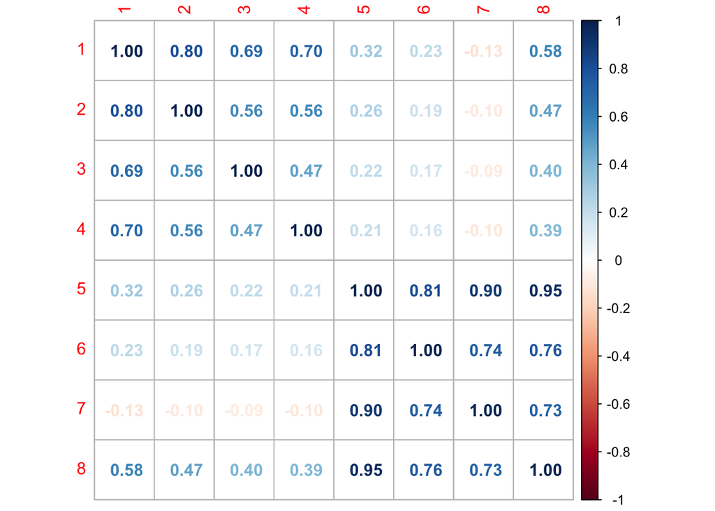

```r
corrplot::corrplot(cor(gendata), method = 'number')
```

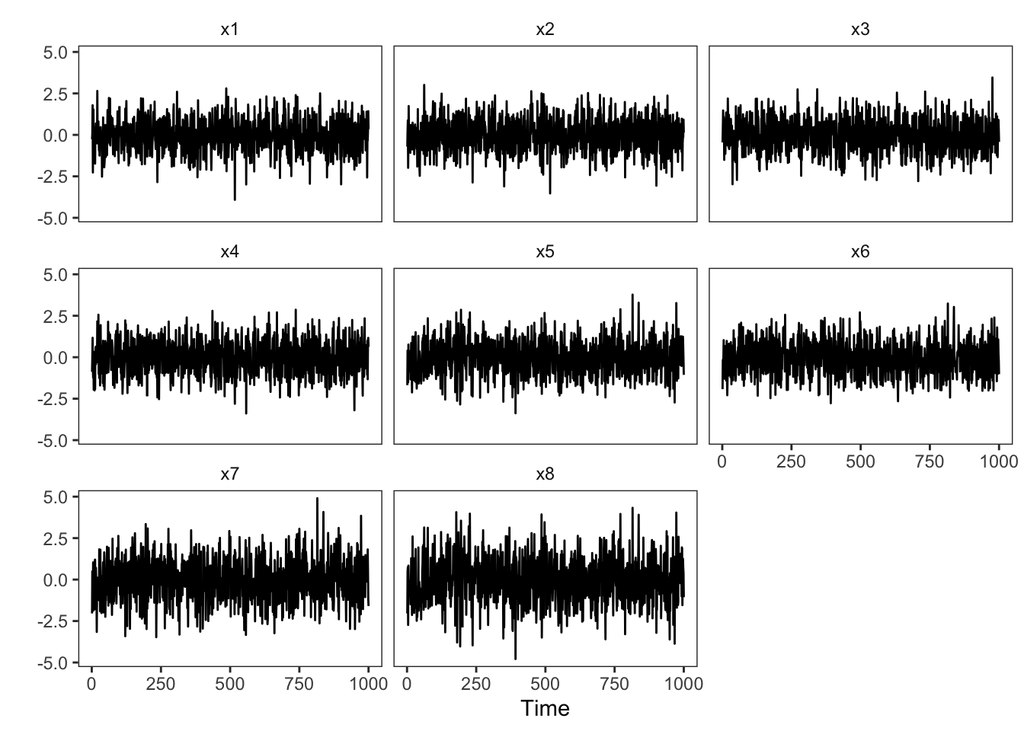

```r
gendata <- cbind(gendata, 1:N)
colnames(gendata) <- c(paste0('x', c(1:8)), 'Time')
gendata_reshape <- reshape2::melt(as.data.frame(gendata), id = "Time")

ggplot(gendata_reshape, aes(Time, value)) + geom_line() +
  theme_bw() + ylab("") +
  facet_wrap(~ variable, ncol = 3) +
  theme(strip.background = element_blank(),
        panel.grid.major = element_blank(),
        panel.grid.minor = element_blank())
```

```r
summary(cfa(model = 'f1=~x1+x2+x3+x4
            f2=~x5+x6+x7+x8',
            data = gendata))
```

```
## Error in h(simpleError(msg, call)): error in evaluating the argument 'object' in selecting a method for function 'summary': lavaan ERROR: sample covariance matrix is not positive-definite
```

```r
summary(miive(model = 'f1=~x1+x2+x3+x4
            f2=~x5+x6+x7+x8',
              data = gendata,
              var.cov = T))
```

```
## Error in h(simpleError(msg, call)): error in evaluating the argument 'object' in selecting a method for function 'summary': system is computationally singular: reciprocal condition number = 6.58998e-17
```

However, this is solved by adding (at least) 2 additional observed variables. AKA, I added 2 extra variables x9 and x10 with very small loading on both factors when simulating which won’t be used for the final simulated data but merely for the sake of keeping x8 follow the model specification. See the code and results below: everything else stays the same besides we added 2 extra variables here.

```r
N <- 1000
mu_latent <- c(0,0) #latent factor means #k=#of latent factors
varcov_latent <- matrix(c(1, .3, #var-cov matrix for latent factors
                .3, 1), nrow = 2, byrow = T)
Lambda <- matrix(c(1, .8, .7, .7, 0, 0, 0, 0, .05, .05, #loadings
                   0, 0, 0, 0, 1, .8, .7, .7, .05, .05), nrow = 10, byrow = F) #p*k matrix.p=#of observed variables.
Lambda
```

```
##       [,1] [,2]
##  [1,] 1.00 0.00
##  [2,] 0.80 0.00
##  [3,] 0.70 0.00
##  [4,] 0.70 0.00
##  [5,] 0.00 1.00
##  [6,] 0.00 0.80
##  [7,] 0.00 0.70
##  [8,] 0.00 0.70
##  [9,] 0.05 0.05
## [10,] 0.05 0.05
```

```r
mu_epsilon <- rep(0, 10)
varcov_epsilon <- diag(c(1-1^2, #standardized
                         1-.8^2,
                         1-.7^2,
                         1-.7^2,
                         1-1^2,
                         1-.8^2,
                         1-.7^2,
                         1-.7^2,
                         1-.05^2-.05^2,
                         1-.05^2-.05^2),
                       nrow = 10)
varcov_epsilon
```

```
##       [,1] [,2] [,3] [,4] [,5] [,6] [,7] [,8]  [,9] [,10]
##  [1,]    0 0.00 0.00 0.00    0 0.00 0.00 0.00 0.000 0.000
##  [2,]    0 0.36 0.00 0.00    0 0.00 0.00 0.00 0.000 0.000
##  [3,]    0 0.00 0.51 0.00    0 0.00 0.00 0.00 0.000 0.000
##  [4,]    0 0.00 0.00 0.51    0 0.00 0.00 0.00 0.000 0.000
##  [5,]    0 0.00 0.00 0.00    0 0.00 0.00 0.00 0.000 0.000
##  [6,]    0 0.00 0.00 0.00    0 0.36 0.00 0.00 0.000 0.000
##  [7,]    0 0.00 0.00 0.00    0 0.00 0.51 0.00 0.000 0.000
##  [8,]    0 0.00 0.00 0.00    0 0.00 0.00 0.51 0.000 0.000
##  [9,]    0 0.00 0.00 0.00    0 0.00 0.00 0.00 0.995 0.000
## [10,]    0 0.00 0.00 0.00    0 0.00 0.00 0.00 0.000 0.995
```

Now x7 and x8 follow the model specification and x9 and x10 behave similarly what x7 and x8 behave in the previous example when x9 and x10 are not simulated. Note that the variance of x4 is a bit small - is this normal?

Additionally, the variance of x1 and x5 estimated using ML and MIIV-2SLS are almost 0. Is this because after taking into account the variances of f1 and f2?

```r
#generate latent factors
set.seed(1234)
zeta <- mvrnorm(n = N,
               mu = mu_latent,
               Sigma = varcov_latent) #n*p matrix
#generate residuals
set.seed(1234)
epsilon <- mvrnorm(n = N,
               mu =mu_epsilon,
               Sigma = varcov_epsilon) #p*n matrix

#### Generate the observed variable series ####
y <- matrix(0, nrow = N, ncol = 10)
for (p in 1:nrow(y)){
  y[p, ] <- Lambda %*% zeta[p, ] + epsilon[p, ]
}
head(y)
```

```
##             [,1]        [,2]       [,3]       [,4]        [,5]       [,6]       [,7]
## [1,] -0.26008265 -0.05813769 -0.7713287 -0.8696869 -1.68625239 -1.3349668 -1.4553734
## [2,]  0.04532048  0.32540832  0.2796520 -0.5493823  0.40202073  0.1986756  0.6485236
## [3,]  1.78487502  1.07746956  0.5923347  1.1105029 -0.03626617 -0.6586539  0.1945727
## [4,] -2.26705234 -1.18801429 -1.7921359 -0.2186300 -1.51527156 -1.2020838  0.2527285
## [5,] -0.06990049  0.77480576 -0.4425161  0.4522331  0.76184326  0.4256689  1.6712088
## [6,]  1.53553081  1.12746609  1.6809258  1.7679825 -0.71954020 -0.4784912 -0.7594819
##            [,8]       [,9]      [,10]
## [1,] -1.8758223 -1.2996331 -1.3013611
## [2,]  0.2102636  0.3230792  0.2991019
## [3,] -0.1044669 -1.4478621  1.1691571
## [4,] -0.2092929  0.4446641 -2.5289423
## [5,] -0.6492488  0.7357893  0.4626477
## [6,] -1.2504168 -1.8603127  0.5455887
```

```r
#identical to the following using matrix computation
gendata <- t(Lambda%*%t(zeta) + t(epsilon)) #transpose of p*n matrix
head(gendata)
```

```
##             [,1]        [,2]       [,3]       [,4]        [,5]       [,6]       [,7]
## [1,] -0.26008265 -0.05813769 -0.7713287 -0.8696869 -1.68625239 -1.3349668 -1.4553734
## [2,]  0.04532048  0.32540832  0.2796520 -0.5493823  0.40202073  0.1986756  0.6485236
## [3,]  1.78487502  1.07746956  0.5923347  1.1105029 -0.03626617 -0.6586539  0.1945727
## [4,] -2.26705234 -1.18801429 -1.7921359 -0.2186300 -1.51527156 -1.2020838  0.2527285
## [5,] -0.06990049  0.77480576 -0.4425161  0.4522331  0.76184326  0.4256689  1.6712088
## [6,]  1.53553081  1.12746609  1.6809258  1.7679825 -0.71954020 -0.4784912 -0.7594819
##            [,8]       [,9]      [,10]
## [1,] -1.8758223 -1.2996331 -1.3013611
## [2,]  0.2102636  0.3230792  0.2991019
## [3,] -0.1044669 -1.4478621  1.1691571
## [4,] -0.2092929  0.4446641 -2.5289423
## [5,] -0.6492488  0.7357893  0.4626477
## [6,] -1.2504168 -1.8603127  0.5455887
```

```r
cov(gendata)
```

```
##             [,1]       [,2]       [,3]       [,4]      [,5]      [,6]      [,7]      [,8]
##  [1,]  0.9306379  0.7275760  0.6640763  0.6168962 0.3095849 0.2352041 0.2149928 0.2402637
##  [2,]  0.7275760  0.9281983  0.5163570  0.4627516 0.2657038 0.1890101 0.1965858 0.1989522
##  [3,]  0.6640763  0.5163570  0.9558690  0.4369182 0.2301219 0.1749743 0.1669071 0.1811658
##  [4,]  0.6168962  0.4627516  0.4369182  0.8894796 0.2081191 0.1328531 0.1570251 0.1735171
##  [5,]  0.3095849  0.2657038  0.2301219  0.2081191 1.0363669 0.8320482 0.7240310 0.7198239
##  [6,]  0.2352041  0.1890101  0.1749743  0.1328531 0.8320482 1.0274222 0.5762689 0.5861072
##  [7,]  0.2149928  0.1965858  0.1669071  0.1570251 0.7240310 0.5762689 1.0094776 0.4985839
##  [8,]  0.2402637  0.1989522  0.1811658  0.1735171 0.7198239 0.5861072 0.4985839 1.0225967
##  [9,] -0.4615605 -0.3397121 -0.3211305 -0.3033641 0.6800029 0.5565253 0.4760901 0.4522922
## [10,]  0.8292394  0.6641280  0.5978799  0.5516228 0.8999320 0.7135876 0.6278513 0.6419350
##             [,9]     [,10]
##  [1,] -0.4615605 0.8292394
##  [2,] -0.3397121 0.6641280
##  [3,] -0.3211305 0.5978799
##  [4,] -0.3033641 0.5516228
##  [5,]  0.6800029 0.8999320
##  [6,]  0.5565253 0.7135876
##  [7,]  0.4760901 0.6278513
##  [8,]  0.4522922 0.6419350
##  [9,]  0.9733043 0.1460552
## [10,]  0.1460552 1.1561608
```

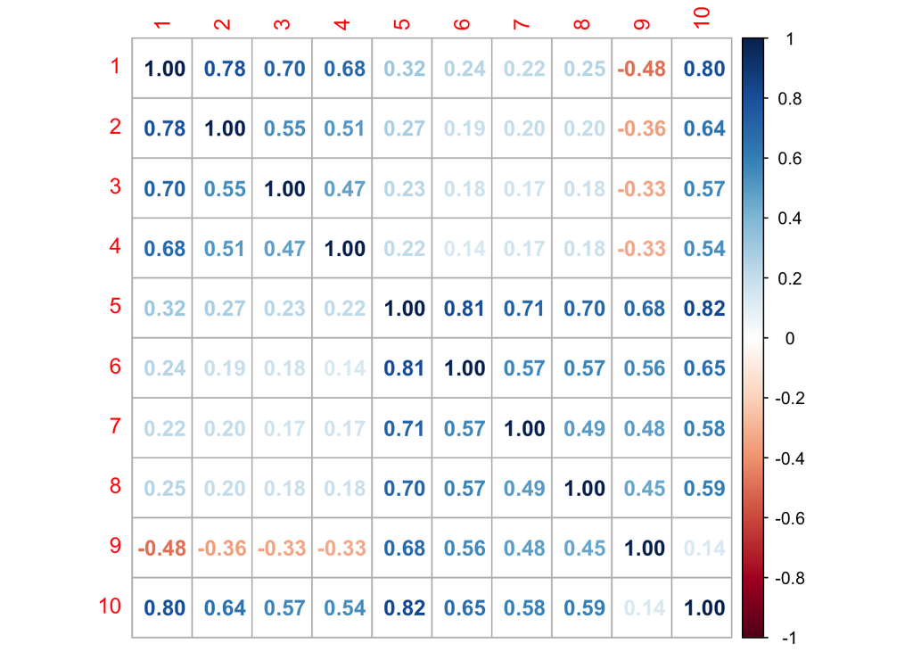

```r
corrplot::corrplot(cor(gendata), method = 'number')
```

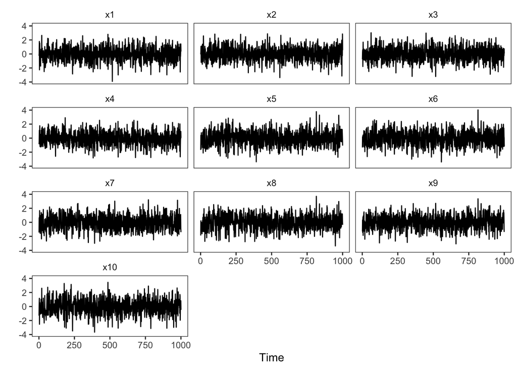

```r
gendata <- cbind(gendata, 1:N)
colnames(gendata) <- c(paste0('x', c(1:10)), 'Time')
gendata_reshape <- reshape2::melt(as.data.frame(gendata), id = "Time")

ggplot(gendata_reshape, aes(Time, value)) + geom_line() +
  theme_bw() + ylab("") +
  facet_wrap(~ variable, ncol = 3) +
  theme(strip.background = element_blank(),
        panel.grid.major = element_blank(),
        panel.grid.minor = element_blank())
```

```r
summary(cfa(model = 'f1=~x1+x2+x3+x4
            f2=~x5+x6+x7+x8',
            data = gendata))
```

```
## lavaan 0.6-10 ended normally after 25 iterations
##
##   Estimator                                         ML
##   Optimization method                           NLMINB
##   Number of model parameters                        17
##
##   Number of observations                          1000
##
## Model Test User Model:
##
##   Test statistic                                14.340
##   Degrees of freedom                                19
##   P-value (Chi-square)                           0.764
##
## Parameter Estimates:
##
##   Standard errors                             Standard
##   Information                                 Expected
##   Information saturated (h1) model          Structured
##
## Latent Variables:
##                    Estimate  Std.Err  z-value  P(>|z|)
##   f1 =~
##     x1                1.000
##     x2                0.773    0.023   33.640    0.000
##     x3                0.705    0.025   28.024    0.000
##     x4                0.656    0.025   26.451    0.000
##   f2 =~
##     x5                1.000
##     x6                0.803    0.022   36.840    0.000
##     x7                0.699    0.024   28.935    0.000
##     x8                0.695    0.025   28.353    0.000
##
## Covariances:
##                    Estimate  Std.Err  z-value  P(>|z|)
##   f1 ~~
##     f2                0.308    0.033    9.485    0.000
##
## Variances:
##                    Estimate  Std.Err  z-value  P(>|z|)
##    .x1               -0.010    0.015   -0.717    0.473
##    .x2                0.365    0.018   19.789    0.000
##    .x3                0.487    0.023   21.293    0.000
##    .x4                0.484    0.022   21.560    0.000
##    .x5                0.000    0.015    0.026    0.980
##    .x6                0.359    0.019   19.282    0.000
##    .x7                0.503    0.024   21.312    0.000
##    .x8                0.522    0.024   21.403    0.000
##     f1                0.940    0.044   21.336    0.000
##     f2                1.035    0.049   21.318    0.000
```

```r
summary(miive(model = 'f1=~x1+x2+x3+x4
            f2=~x5+x6+x7+x8',
              data = gendata,
              var.cov = T))
```

```
## MIIVsem (0.5.8) results
##
## Number of observations                                                   1000
## Number of equations                                                         6
## Estimator                                                           MIIV-2SLS
## Standard Errors                                                      standard
## Missing                                                              listwise
##
##
## Parameter Estimates:
##
##
## STRUCTURAL COEFFICIENTS:
##                    Estimate  Std.Err  z-value  P(>|z|)   Sargan   df   P(Chi)
##   f1 =~
##     x1                1.000
##     x2                0.769    0.024   31.805    0.000    5.816    5    0.325
##     x3                0.710    0.027   26.569    0.000    0.504    5    0.992
##     x4                0.645    0.027   24.189    0.000    5.952    5    0.311
##   f2 =~
##     x5                1.000
##     x6                0.803    0.023   35.409    0.000    6.600    5    0.252
##     x7                0.694    0.026   27.131    0.000    1.749    5    0.883
##     x8                0.702    0.026   27.123    0.000    2.375    5    0.795
##
## INTERCEPTS:
##                    Estimate  Std.Err  z-value  P(>|z|)
##     x1                0.000
##     x2                0.027    0.019    1.409    0.159
##     x3                0.033    0.022    1.494    0.135
##     x4               -0.030    0.022   -1.346    0.178
##     x5                0.000
##     x6               -0.004    0.019   -0.193    0.847
##     x7               -0.007    0.022   -0.309    0.757
##     x8                0.021    0.023    0.906    0.365
##
## VARIANCES:
##                    Estimate  Std.Err  z-value  P(>|z|)
##     f1                0.942
##     f2                1.035
##     x1               -0.012
##     x2                0.366
##     x3                0.488
##     x4                0.485
##     x5                0.001
##     x6                0.359
##     x7                0.503
##     x8                0.522
##
## COVARIANCES:
##                    Estimate  Std.Err  z-value  P(>|z|)
##   f1 ~~
##     f2                0.308
```